# Os gastos refletem as desigualdades?

Jessica Voigt

3 de fevereiro de 2020

## Desigualdade

Queremos verificar se os gastos com pagamentos de professores no Estado de São Paulo de alguma forma refletem desigualdades.

Há duas abordagens possíveis para aferir essas desigualdade: * Desigualdade regional : IDH, saneamento básico, etc; * Desigualdade em desempenho: Índices

É provável que esses dois tipos de desigualdades estão fortemente correlacionados, mas neste momento ainda não vamos testar essa hipótese. Optamos por iniciar o debate sobre desigualdade com a seguinda abordagem, olhando primeiramente os resultados do IDEB

### IDEB:

Do site do INEP:

*O Índice de Desenvolvimento da Educação Básica (Ideb) é uma iniciativa do Instituto Nacional de Estudos e Pesquisas Educacionais Anísio Teixeira (Inep) para mensurar o desempenho do sistema educacional brasileiro a partir da combinação entre a proficiência dos estudantes, obtida no Sistema de Avaliação da Educação Básica (Saeb), e o indicador de taxa de aprovação, que tem influência na eficiência do fluxo escolar e é obtido por meio do Censo Escolar.*

*Essas duas dimensões, que refletem problemas estruturais da educação básica brasileira, precisam ser aprimoradas para que o país alcance níveis educacionais compatíveis com seu potencial de desenvolvimento e para garantia do direito educacional expresso em nossa constituição federal. Pela própria construção matemática do indicador (taxa de troca entre as duas dimensões), para elevar o Ideb, as redes de ensino e as escolas precisam melhorar as duas dimensões do indicador, simultaneamente, uma vez que a natureza do Ideb dificulta a sua elevação, considerando apenas a melhoria de uma dimensão em detrimento da outra.*

Mais informações aqui

## Cruzamentos

```r
library(dplyr)
library(ggplot2)
library(tidyr)
library(data.table)
library(janitor)
library(kableExtra)

#Dados SIOPE
load("~/R-Projects/qualidade_gastos_educação/analise_gastos_siope/data/rem_prof_sp.Rdata")

#Tabela com os códigos das escolas
escolas = fread("~/R-Projects/qualidade_gastos_educação/analise_gastos_siope/tabela_escolas_sp/tabela_end_escolas_completa.csv", encoding = "UTF-8")

#Juntando:
escolas2 <- escolas %>%
  distinct(nome_escola_siope , municipio, .keep_all = TRUE) %>%
  select(nome_escola_siope , municipio, end2, lon, lat, codigo_escola, codigo_mec) %>%
  rename(NO_MUNICIPIO = municipio,
         LOCAL_EXERCICIO = nome_escola_siope )

df <- rem_prof_sp %>%
  left_join(escolas2, by=c("NO_MUNICIPIO", "LOCAL_EXERCICIO"))
```

Distribuição do gasto médio com salário por escola:

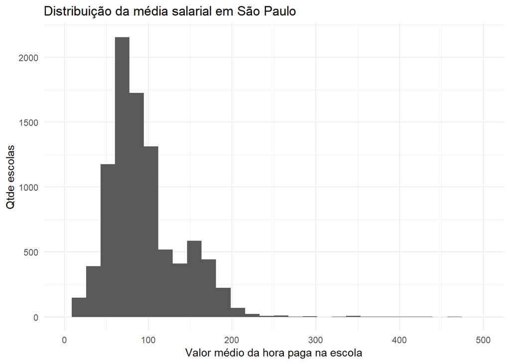

```r
bx <- 0

for(i in 1:10){
  a <- i*25
  bx <- c(bx, a)
}

df %>%
  mutate(valor_hora = round(VL_SALARIO / CARGA_HORARIA,0 )) %>%
  group_by(codigo_escola) %>%
  summarise(valor_medio_hora = mean(valor_hora)) %>%
  ggplot(aes(valor_medio_hora)) +
  geom_histogram(show.legend = TRUE) +
  labs(x = "Valor médio da hora paga na escola", y = "Qtde escolas") +
  theme_minimal() + xlim(0,500) +
  ggtitle("Distribuição da média salarial em São Paulo")
```

Tabela com a categoria profissional e o valor médio por hora:

```r
df %>%
  mutate(valor_hora = round(VL_SALARIO / CARGA_HORARIA,0 )) %>%
  group_by(CATEG_PROFISSIONAL) %>%
  summarise(valor_medio_hora = mean(valor_hora)) %>%
  kable()
```

| CATEG_PROFISSIONAL | valor_medio_hora |
| --- | --- |
| Auxiliar/Assistente Educacional | 49.85233 |
| Docente graduado bacharél e tecnólogo com diploma de mestrado ou doutorado na área do componente cur | 106.50617 |
| Docente habilitado em curso de licenciatura plena | 118.50901 |
| Docente habilitado em curso de nível médio | 91.78292 |
| Docente habilitado em curso de pedagogia | 120.09068 |
| Docente habilitado em programa especial de formação pedagogica de docentes | 93.13891 |
| Docente instrutor, tradutor e intérprete de libras | 83.24152 |
| Docente pós-graduado em cursos de especialização para formação de docentes para educação profissiona | 96.50184 |
| Docente professor de comunidade quilombola | 115.75000 |
| Docente professor indígena sem prévia formação pedagógica | 71.68750 |
| Profissionais em efetivo exercício no âmbito da educação infantil e ensino fundamental. | 124.22336 |
| Profissionais experientes, não graduados, autorizados a atuar como docentes, em caráter precário e p | 67.20690 |
| Profissionais graduados, bacharéis e tecnólogos autorizados a atuar como docentes, em caráter precár | 91.41326 |
| Profissionais não habilitados, porém autorizados a exercer a docência em caráter precário e provisór | 319.71846 |
| Profissionais que atuam na realização das atividades requeridos nos ambientes de secretaria, de manu | 41.45968 |
| Profissionais que exercem funções de secretaria escolar, alimentação escolar (merendeiras), multimei | 52.15718 |